# IT5100F Project Group 3

View this notebook in: [Google Colab](https://colab.research.google.com/drive/1L6fdPSCIR2stlJXei2Ab1EtbIYaSyMo2?usp=sharing) [Github Pages](https://github.com/foongming/foongming.github.io/tree/main/it5100f) [Github](https://github.com/foongming/foongming.github.io/blob/main/it5100f/IT5100F.html)

**Table of Contents**

> AI Tools Usage Disclaimer

> Introduction

> Part 1: Data Preprocessing

> > 1.1 Data Loading

> > 1.2 Data Cleaning

> > 1.3 Data Transformation

> > 1.4 Data Storage

> Part 2: EDA & Data Visualization

> > 2.1 Unique Sports Analysis

> > 2.2 Plot Workouts by Sport

> > 2.3 Heatmap Visualization

> Part 3: Modelling (Supervised Learning - Regression)

> > 3.1: Data Loading

> > 3.2: Data Preperation and Feature Engineering

> > 3.3: Model Training and Application

> > 3.4 Model Evaluation and Visualization

> > 3.5: Model Improvement with More Features (Multivariate Regression)

> > 3.6: Model Comparison

> Part 4: Modelling (Classification)

> > 4.1: Data Preprocessing

> > 4.2: Determine the Optimal Number of Clusters

> > 4.3: Cluster Visualization & Analysis

> > 4.4 Identify Similar Users

> Part 5: Free-form Exploration

> > 5.1: Problem definition

> > 5.2: Solution

> > > 5.2.1 Preprocessing of dataset

> > > 5.2.2 Splitting of dataset into Training and Testing

> > > 5.2.3 Feature Selection

> > > 5.2.4 Modelling

> > > 5.2.5 Performance Metrics

# AI Tools Usage Disclaimer

AI tools such as ChatGPT and GitHub Copilot were used to help generate some code used in this report.

# Introduction

This report provides an in-depth analysis of the Endomondo Dataset, which comprises sport records collected from the Endomondo fitness tracking platform. The dataset includes various sensory data such as heart rate, speed, and GPS coordinates, recorded from multiple users during their workout sessions.

The primary objectives of this report are to conduct exploratory data analysis (EDA) to uncover insights from the data and to develop practical solutions that can be derived from these insights. The key steps involved in this analysis are as follows:

- **Data Preprocessing:** This step involves cleaning and transforming the raw data to ensure its quality and consistency. It includes handling missing values, ensuring data consistency, and converting data types as necessary.
- **Data Visualization:** In this step, various visualization techniques are employed to represent the data graphically. This helps in understanding the distribution, trends, and patterns within the data.
- **Data Modeling:** This involves applying both supervised and unsupervised machine learning techniques to the preprocessed data. The goal is to build predictive models and derive actionable insights that can be used for various applications.

Additionally, as part of the course assignment, this report includes a guided analysis. Beyond the guided steps, the report also presents a freeform analysis conducted by the team, which explores additional potential applications of the dataset. This comprehensive approach ensures a thorough understanding and utilization of the available data.

**Import Libraries**

This code block imports several essential libraries for data analysis and visualization in Python:

- pandas (imported as pd): Used for data manipulation and analysis, particularly with data structures like DataFrames.
- numpy (imported as np): Provides support for large, multi-dimensional arrays and matrices, along with a collection of mathematical functions.
- matplotlib.pyplot (imported as plt): A plotting library used for creating static, interactive, and animated visualizations.
- seaborn (imported as sns): A statistical data visualization library based on Matplotlib, providing a high-level interface for drawing attractive and informative statistical graphics.
- json: A library for parsing JSON (JavaScript Object Notation), a lightweight data interchange format.

```python
import pandas as pd
import numpy as np
import matplotlib.pyplot as plt
import seaborn as sns
import json
```

# Part 1: Data Preprocessing

In this Data Preprocessing part, we perform crucial step in any data analysis or machine learning project. It involves transforming raw data into a clean and usable format. This step ensures that the data is consistent, accurate, and ready for analysis. The main tasks involved in data preprocessing are as follow:

## 1.1 Data Loading

Firstly, the report starts with loading the datasets into the notebook. Due to the large size of datasets, data is stored in google drive. This setup allows the team to save storage space by referring to the same source of data consistently. Then, data is read as json format with multiple lines delimiter and then we store the data into `endomondo_df` variable

```python
# Mount GoogleDrive
from google.colab import drive
drive.mount('/content/drive')

# Read the JSON file as a Data Frame
endomondo_df = pd.read_json('/content/drive/MyDrive/Colab Notebooks/endomondo_proper.json', lines=True)

# Display the first few rows of the DataFrame
endomondo_df.head()
```

|  | altitude | heart_rate | id | latitude | longitude | speed | sport | timestamp |
| --- | --- | --- | --- | --- | --- | --- | --- | --- |
| 0 | [41.6, 40.6, 40.6, 38.4, 37.0, 34.0, 34.0, 34.... | [100, 111, 120, 119, 120, 116, 125, 128, 131, ... | 396826535.0 | [60.1733487658, 60.1732398011, 60.1729802135, ... | [24.6497704089, 24.650142733, 24.650910683, 24... | [6.8652, 16.4736, 19.1988, 20.4804, 31.3956, 3... | bike | [1408898746, 1408898754, 1408898765, 140889877... |
| 1 | [38.4, 39.0, 39.0, 38.2, 36.8, 36.8, 36.8, 35.... | [100, 105, 111, 110, 108, 115, 126, 130, 132, ... | 392337038.0 | [60.1732475962, 60.1732096262, 60.1729796268, ... | [24.6498552337, 24.6501554735, 24.6508813463, ... | [9.0792, 13.284, 15.9336, 10.9476, 16.1676, 30... | bike | [1408221682, 1408221687, 1408221699, 140822170... |
| 2 | [28.6, 29.4, 29.4, 29.4, 28.0, 27.0, 25.2, 23.... | [99, 105, 113, 109, 112, 116, 116, 114, 114, 1... | 386729739.0 | [60.1732862368, 60.1732394658, 60.1730676368, ... | [24.6498743445, 24.6502427291, 24.6508224215, ... | [7.4988, 15.4008, 17.8668, 21.5712, 24.1416, 3... | bike | [1407432042, 1407432048, 1407432056, 140743206... |
| 3 | [24.0, 24.0, 24.0, 21.0, 18.6, 17.4, 17.4, 17.... | [118, 118, 119, 120, 122, 124, 126, 129, 133, ... | 381185226.0 | [60.173279196, 60.1732723229, 60.1732617617, 6... | [24.6498169284, 24.6498684771, 24.6500092093, ... | [7.218, 9.8208, 14.3532, 16.2972, 20.1276, 20.... | bike (transport) | [1406647079, 1406647080, 1406647082, 140664708... |
| 4 | [21.2, 22.0, 22.0, 20.6, 19.8, 19.4, 17.6, 15.... | [100, 98, 104, 104, 107, 109, 108, 105, 105, 1... | 371302193.0 | [60.1732459199, 60.173199987, 60.1730691455, 6... | [24.650183385200002, 24.6504225209, 24.6508663... | [16.4124, 11.682, 18.162, 21.7728, 24.408, 26.... | bike | [1405100572, 1405100576, 1405100582, 140510059... |

## 1.2 Data Cleaning

Data cleaning is a critical step in the data preprocessing phase. It involves identifying and correcting errors or inconsistencies in the dataset to ensure the quality and reliability of the data. One of the primary tasks in data cleaning is dealing with null or missing values. Missing values can occur due to various reasons such as data entry errors, incomplete data collection, or merging datasets from different sources.

In this section, we will cover the following steps to handle null values:

1. **Identifying Missing Values**: Detecting which columns and rows contain null values.
2. **Handling Missing Values**: Choosing an appropriate strategy to deal with missing values, such as:
   - **Removing Missing Values**: Dropping rows or columns with null values.
   - **Imputing Missing Values**: Replacing null values with a specific value, such as the mean, median, or mode of the column, or using more advanced techniques like interpolation or predictive modeling.
3. **Validating Data**: Ensuring that the data cleaning steps have been correctly applied and that the dataset is now free of null values.

By effectively dealing with null values, we can improve the quality of our dataset and ensure that our analysis and models are based on accurate and complete data.

```python
#Display the shape of the dataframe
print(endomondo_df.shape)
```

```
(21391, 8)
```

In this step we first start with identifying total number of missing values in the dataset

```python
# TODO: Find the total number of missing rows with null values in any column
total_missing = endomondo_df.isnull().any(axis=1).sum()

# Print the total number of missing values
print(total_missing)
```

```
2000
```

Once we have identified there are 2000 rows with missing values, we proceed to drop those rows with `dropna()` function

```python
# TODO: Clean the data by removing rows with missing values
endomondo_cleaned_df = endomondo_df.dropna()
print(endomondo_cleaned_df.shape)
```

```
(19391, 8)
```

Then we further check for validate to ensure the missing values have been promptly removed

```python
# TODO: Check the results of data cleaning
total_cleaned_missing = endomondo_cleaned_df.isnull().sum()
print(total_cleaned_missing)
```

```
altitude      0
heart_rate    0
id            0
latitude      0
longitude     0
speed         0
sport         0
timestamp     0
dtype: int64
```

## 1.3 Data Transformation

Data transformation involves converting data into a suitable format or structure for analysis and modeling. This step ensures that the data is consistent, accurate, and ready for further processing. The main tasks involved in data transformation include:

- **Ensure Data Consistency**:
  - Standardize data formats (e.g., date formats, categorical values).
  - Ensure consistent units of measurement (e.g., converting all distances to kilometers).
  - Harmonize data from different sources to ensure uniformity.
- **Transform the Dataset**:
  - Normalize or scale numerical features to bring them to a common scale without distorting differences in the ranges of values.
  - Encode categorical variables using techniques such as one-hot encoding or label encoding.
  - Aggregate or disaggregate data as needed (e.g., summarizing daily data to monthly data).
- **Convert Timestamps**:
  - Parse and convert date and time information into a standardized datetime format.
  - Extract useful features from timestamps, such as year, month, day, hour, minute, and second.
  - Handle time zone conversions if necessary.
- **Check and Remove Null Values, if Any**:
  - Identify any remaining null values in the dataset.
  - Apply appropriate strategies to handle null values, such as imputation or removal.
  - Validate that the dataset is free of null values after transformation.

By performing these data transformation tasks, we ensure that our dataset is clean, consistent, and ready for analysis and modeling. This step is essential for improving the performance and accuracy of machine learning models.

As a start, we firstly create new columns that counts the number of available data in the each of the feature columns (e.g. altitude, heart_rate, speed, latitude, longitude and timestamp).

We store this dataframe into another copy (named `copy`) to preserve the main `endomondo_df` dataframe

```python
# TODO: Ensure consistency by verifying that the number of entries in the altitude, latitude, longitude, timestamp, heart_rate, and speed arrays is the same for each id

#create a copy of the df
copy = endomondo_cleaned_df.copy()

#first add a column to the df for the count of each element
copy['altitude_lens'] = copy['altitude'].apply(len)
copy['heart_rate_lens'] = copy['heart_rate'].apply(len)
copy['speed_lens'] = copy['speed'].apply(len)
copy['latitude_lens'] = copy['latitude'].apply(len)
copy['longitude_lens'] = copy['longitude'].apply(len)
copy['timestamp_lens'] = copy['timestamp'].apply(len)
```

```python
#Check columns are added to the copy properly
copy.head()
```

|  | altitude | heart_rate | id | latitude | longitude | speed | sport | timestamp | altitude_lens | heart_rate_lens | speed_lens | latitude_lens | longitude_lens | timestamp_lens |
| --- | --- | --- | --- | --- | --- | --- | --- | --- | --- | --- | --- | --- | --- | --- |
| 0 | [41.6, 40.6, 40.6, 38.4, 37.0, 34.0, 34.0, 34.... | [100, 111, 120, 119, 120, 116, 125, 128, 131, ... | 396826535.0 | [60.1733487658, 60.1732398011, 60.1729802135, ... | [24.6497704089, 24.650142733, 24.650910683, 24... | [6.8652, 16.4736, 19.1988, 20.4804, 31.3956, 3... | bike | [1408898746, 1408898754, 1408898765, 140889877... | 500 | 500 | 500 | 500 | 500 | 500 |
| 1 | [38.4, 39.0, 39.0, 38.2, 36.8, 36.8, 36.8, 35.... | [100, 105, 111, 110, 108, 115, 126, 130, 132, ... | 392337038.0 | [60.1732475962, 60.1732096262, 60.1729796268, ... | [24.6498552337, 24.6501554735, 24.6508813463, ... | [9.0792, 13.284, 15.9336, 10.9476, 16.1676, 30... | bike | [1408221682, 1408221687, 1408221699, 140822170... | 500 | 500 | 500 | 500 | 500 | 500 |
| 2 | [28.6, 29.4, 29.4, 29.4, 28.0, 27.0, 25.2, 23.... | [99, 105, 113, 109, 112, 116, 116, 114, 114, 1... | 386729739.0 | [60.1732862368, 60.1732394658, 60.1730676368, ... | [24.6498743445, 24.6502427291, 24.6508224215, ... | [7.4988, 15.4008, 17.8668, 21.5712, 24.1416, 3... | bike | [1407432042, 1407432048, 1407432056, 140743206... | 500 | 500 | 500 | 500 | 500 | 500 |
| 3 | [24.0, 24.0, 24.0, 21.0, 18.6, 17.4, 17.4, 17.... | [118, 118, 119, 120, 122, 124, 126, 129, 133, ... | 381185226.0 | [60.173279196, 60.1732723229, 60.1732617617, 6... | [24.6498169284, 24.6498684771, 24.6500092093, ... | [7.218, 9.8208, 14.3532, 16.2972, 20.1276, 20.... | bike (transport) | [1406647079, 1406647080, 1406647082, 140664708... | 500 | 500 | 500 | 500 | 500 | 500 |
| 4 | [21.2, 22.0, 22.0, 20.6, 19.8, 19.4, 17.6, 15.... | [100, 98, 104, 104, 107, 109, 108, 105, 105, 1... | 371302193.0 | [60.1732459199, 60.173199987, 60.1730691455, 6... | [24.650183385200002, 24.6504225209, 24.6508663... | [16.4124, 11.682, 18.162, 21.7728, 24.408, 26.... | bike | [1405100572, 1405100576, 1405100582, 140510059... | 500 | 500 | 500 | 500 | 500 | 500 |

Then we check for any inconsistencies between the columns count, by creating a function called `check_length`. This function is being applied to the `copy` dataframe by filtering with this function to only show the rows with inconsistent values among the features.

In this result, the dataframe proven to have no inconsistent rows.

```python
# Check if there are any rows with len(latitude) != len(longitude) != len(altitude) != len(timestamp) != len(heart_rate) != len(speed)

#Group the dataframe by ID
grouped = copy.groupby('id')

#Create a function that checks for the lengths of the specific columns and ensure they are unique (identical)
def check_length(group):
    length = group[['altitude_lens', 'heart_rate_lens', 'speed_lens', 'latitude_lens','longitude_lens','timestamp_lens']]
    return length.nunique(axis=1).eq(1).all()

#find inconsistent rows
inconsistent_rows = copy.groupby('id').filter(lambda x: not check_length(x))

# Print the inconsistent rows
print(inconsistent_rows)
```

```
Empty DataFrame
Columns: [altitude, heart_rate, id, latitude, longitude, speed, sport, timestamp, altitude_lens, heart_rate_lens, speed_lens, latitude_lens, longitude_lens, timestamp_lens]
Index: []
```

We then transforms a dataset by expanding arrays into individual columns. It specifies columns to expand (altitude, latitude, longitude, timestamp, heart_rate, speed) and the desired column order.

The explode function is used to expand these columns, ensuring each column holds a single value from the array.

The DataFrame is then reordered according to the specified column order.

Finally, the shape and columns of the new DataFrame are printed to verify the transformation, ensuring the expanded DataFrame has the expected number of rows and columns.

```python
# TODO: Transform the dataset by expanding each array (altitude, latitude, longitude, timestamp, heart_rate, speed) associated with id into individual columns, making sure each column holds a single value from the array.

columns_to_expand = ['altitude', 'latitude', 'longitude', 'timestamp', 'heart_rate', 'speed']
reorder_cols = ['id', 'latitude', 'longitude', 'altitude', 'timestamp', 'sport', 'speed', 'heart_rate']

#explode 6 columns in df
endomondo_expanded_df = endomondo_cleaned_df.explode(columns_to_expand)

#required ordering as per assignment
endomondo_expanded_df = endomondo_expanded_df[reorder_cols]

# Verify the shape of the new DataFrame
# - Check that the array size makes sense. Shape of endomondo_cleaned_df = 19391, 8
# - Each array has 500 entries
# - Each exploded column should have 19391*500 = 9695500 rows

print(endomondo_expanded_df.shape)
print(endomondo_expanded_df.columns)
```

```
(9695500, 8)
Index(['id', 'latitude', 'longitude', 'altitude', 'timestamp', 'sport',
       'speed', 'heart_rate'],
      dtype='object')
```

```python
endomondo_expanded_df.head()
```

|  | id | latitude | longitude | altitude | timestamp | sport | speed | heart_rate |
| --- | --- | --- | --- | --- | --- | --- | --- | --- |
| 0 | 396826535.0 | 60.173349 | 24.64977 | 41.6 | 1408898746 | bike | 6.8652 | 100 |
| 0 | 396826535.0 | 60.17324 | 24.650143 | 40.6 | 1408898754 | bike | 16.4736 | 111 |
| 0 | 396826535.0 | 60.17298 | 24.650911 | 40.6 | 1408898765 | bike | 19.1988 | 120 |
| 0 | 396826535.0 | 60.172478 | 24.650669 | 38.4 | 1408898778 | bike | 20.4804 | 119 |
| 0 | 396826535.0 | 60.171861 | 24.649145 | 37.0 | 1408898794 | bike | 31.3956 | 120 |

Once the dataframe has been properly arranged with explode and column reordering. We convert the timestamp column from seconds into datetime object

```python
# TODO: Convert the timestamp column from seconds to a datetime object.
endomondo_expanded_df["timestamp"] = pd.to_datetime(endomondo_expanded_df['timestamp'], unit='s')
```

```python
# Inspect the data
endomondo_expanded_df.head()
```

|  | id | latitude | longitude | altitude | timestamp | sport | speed | heart_rate |
| --- | --- | --- | --- | --- | --- | --- | --- | --- |
| 0 | 396826535.0 | 60.173349 | 24.64977 | 41.6 | 2014-08-24 16:45:46 | bike | 6.8652 | 100 |
| 0 | 396826535.0 | 60.17324 | 24.650143 | 40.6 | 2014-08-24 16:45:54 | bike | 16.4736 | 111 |
| 0 | 396826535.0 | 60.17298 | 24.650911 | 40.6 | 2014-08-24 16:46:05 | bike | 19.1988 | 120 |
| 0 | 396826535.0 | 60.172478 | 24.650669 | 38.4 | 2014-08-24 16:46:18 | bike | 20.4804 | 119 |
| 0 | 396826535.0 | 60.171861 | 24.649145 | 37.0 | 2014-08-24 16:46:34 | bike | 31.3956 | 120 |

Then at the end of the process, we proceed with further verifying that there is no missing values in the dataframe

```python
# TODO: Check and ensure there are no null values in the dataset after the transformation.
total_missing = endomondo_expanded_df.isnull().sum()

# Print the total number of missing values
print(total_missing)
```

```
id            0
latitude      0
longitude     0
altitude      0
timestamp     0
sport         0
speed         0
heart_rate    0
dtype: int64
```

## 1.4 Data Storage

This part is where the processed dataset is being stored into CSV file for future usage or storage. This is especially useful when working with Google Colab which allows us to save runtime resources for the subsequent part of the report.

```python
CSV_FILE_NAME = "endomondo_proper_cleaned_expanded.csv"
# TODO 1: Save the cleaned and transformed dataset to a new CSV file with the CSV_FILE_NAME
endomondo_expanded_df.to_csv(CSV_FILE_NAME, index=False)
```

# Part 2: EDA & Data Visualization

Exploratory Data Analysis (EDA) and Data Visualization are essential steps in understanding the underlying patterns, trends, and relationships within your dataset. Before diving into this part, ensure that you have completed Part 1: Data Preprocessing, as it prepares the data for meaningful analysis.

In this section, the report will cover the following:

1. **Exploratory Data Analysis (EDA)**:
   - **Descriptive Statistics**: Summarize the main characteristics of the dataset, including measures of central tendency (mean, median) and measures of variability (standard deviation, variance).
   - **Data Distribution**: Analyze the distribution of individual variables using histograms, box plots, and density plots.
   - **Correlation Analysis**: Examine the relationships between different variables using correlation matrices and scatter plots.
   - **Outlier Detection**: Identify and analyze outliers that may affect the results of your analysis.
2. **Data Visualization**:
   - **Univariate Analysis**: Visualize the distribution of individual variables using bar charts, histograms, and pie charts.
   - **Bivariate Analysis**: Explore the relationships between two variables using scatter plots, line plots, and heatmaps.
   - **Multivariate Analysis**: Investigate the interactions between multiple variables using pair plots, 3D plots, and parallel coordinates plots.
   - **Time Series Analysis**: Analyze and visualize time-dependent data using line plots, seasonal decomposition, and autocorrelation plots.

By performing EDA and Data Visualization, we gain valuable insights into the dataset, identify patterns and anomalies, and generate hypotheses for further analysis. These steps are crucial for making informed decisions and building robust predictive models.

We start the process by loading the previously saved .CSV dataset

```python
# TODO: Load the data
CSV_FILE_NAME = "endomondo_proper_cleaned_expanded.csv"
endomondo_df = pd.read_csv(CSV_FILE_NAME)
```

```python
endomondo_df.head()
```

|  | id | latitude | longitude | altitude | timestamp | sport | speed | heart_rate |
| --- | --- | --- | --- | --- | --- | --- | --- | --- |
| 0 | 396826535.0 | 60.173349 | 24.649770 | 41.6 | 2014-08-24 16:45:46 | bike | 6.8652 | 100 |
| 1 | 396826535.0 | 60.173240 | 24.650143 | 40.6 | 2014-08-24 16:45:54 | bike | 16.4736 | 111 |
| 2 | 396826535.0 | 60.172980 | 24.650911 | 40.6 | 2014-08-24 16:46:05 | bike | 19.1988 | 120 |
| 3 | 396826535.0 | 60.172478 | 24.650669 | 38.4 | 2014-08-24 16:46:18 | bike | 20.4804 | 119 |
| 4 | 396826535.0 | 60.171861 | 24.649145 | 37.0 | 2014-08-24 16:46:34 | bike | 31.3956 | 120 |

## 2.1 Unique Sports Analysis

In this section we want to find out the number of unique sports in the dataset, we use `nunique()` function to check for the unique values in specific to the `sport` column in the `endomondo_df` dataframe

```python
# TODO: Find the total number of unique sports in the dataset
num_unique_sports = endomondo_df['sport'].nunique()
print("Total number of unique sports in the dataset: ", num_unique_sports)
```

```
Total number of unique sports in the dataset:  14
```

## 2.2 Plot Workouts by Sport

This part we plot the number of workouts associated with each sport in the form of bar plot

We perform quick removal of any duplicate IDs, then from the unique dataframe, we perform value count of each row and store it as an array

Once processed we proceed with plotting bar chart with matplotlib library

Based on the result shown, the dataset is mostly dominated by 2 main sports which are `Bike` and `Run`

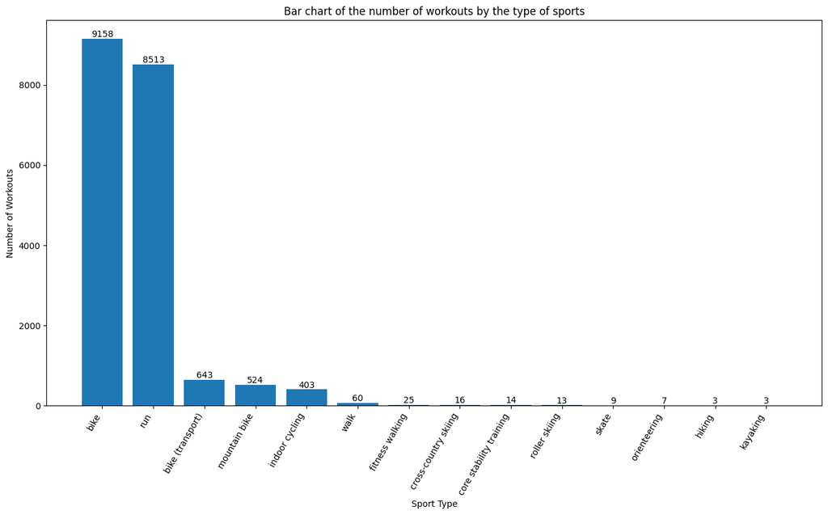

```python
# TODO: Create a bar chart that visualizes the number of workouts associated with each sport.

# Step 1: Drop duplicate IDs
df_unique = endomondo_df.drop_duplicates(subset='id')

#Step 2: Category type is needed here
sportByType = df_unique['sport'].astype( "category" )
sportByType = sportByType.value_counts()

#Plot the bar chart
cat = np.array( sportByType.index.values )

# Convert the count table into a numpy array
ht = sportByType.to_numpy()

plt.figure(figsize=(16, 8))

# Rotate x-axis labels more steeply and reduce font size
plt.xticks(rotation=60, ha='right', fontsize=10)

plt.xlabel( "Sport Type" )
plt.ylabel( "Number of Workouts" )
plt.title( "Bar chart of the number of workouts by the type of sports" )

bars = plt.bar(cat, ht)

# Add numbers above each bar
for bar in bars:
    height = bar.get_height()
    plt.text(bar.get_x() + bar.get_width() / 2.0, height, str(int(height)),
             ha='center', va='bottom')

plt.show()
```

## 2.3 Heatmap Visualization

In this section we further expand the visualization of `altitude` by `latitude` and `longitude` with heatmap. To achieve this, we take the copy of the `endomondo_df` data frame with the `USER_ID` provided and store it into `filtered_df`. Then, we convert the filtered_df into pivot_table with `latitude` as index, `longitude` as columns, `altitude` as values and `mean` as aggregate function.

Then we use matplotlib and seaborn libraries to plot the heatmap accordingly. As part of the requirement, we use pallete name `viridis` for the visualization.

**Option 1: Generate a heatmap with standalone values**

In the option 1, we take dataframe as-is from the processed dataset in previous sections.

This approach of visualization leads to very granular data points and resulted into unclear heatmap visualization with very thin lines. Therefore, the team decided to explore another option to allow clearer visualization.

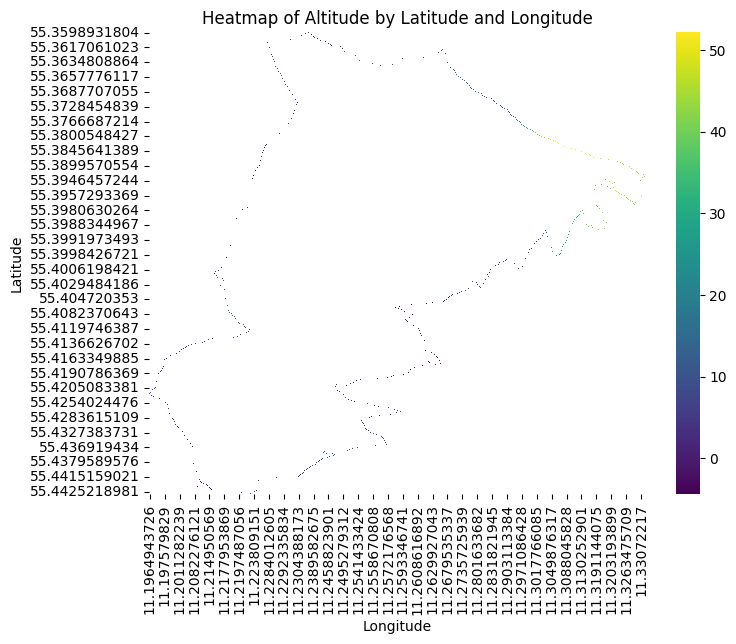

```python
# TODO: Plot Heatmap with longitude and latitude on the x and y axes, respectively, and color the points based on the Altitude.

USER_ID = 9633831
filtered_df = endomondo_df[endomondo_df['id'] == USER_ID].copy()
heatmap_a_df = filtered_df[['altitude','latitude','longitude']]
data_pivot_a = heatmap_a_df.pivot_table(index='latitude', columns='longitude', values='altitude', aggfunc='mean')

PALLETE_NAME = "viridis"
# TODO: Plot Heatmap with longitude and latitude on the x and y axes, respectively, and color the points based on the Altitude.

# Create the heatmap
plt.figure(figsize=(8, 6))
sns.heatmap(data_pivot_a, cmap= PALLETE_NAME, annot=False, cbar=True)

# Set axis labels and title
plt.xlabel('Longitude')
plt.ylabel('Latitude')
plt.title('Heatmap of Altitude by Latitude and Longitude')

# Show the plot
plt.show()
```

**Option 2: Generate heatmap with rounding up values to create bin range**

In this option, the team explores generating a heatmap by rounding values to create bin ranges and reduce granularity. This approach groups individual data points, resulting in a clearer and more interpretable heatmap. It also allows, reader to interprate the intensity of the color better compared to the option 1.

NaN accurately reflects the data by showing that there are no altitude readings for those areas, which visually indicates where the individual hasn't travelled.

The same USER_ID and color pallette were used for consistency and requirement

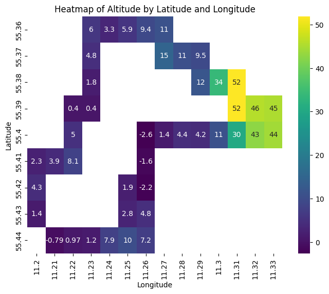

```python
# TODO: Plot Heatmap with longitude and latitude on the x and y axes, respectively, and color the points based on the Altitude.

USER_ID = 9633831
filtered_df = endomondo_df[endomondo_df['id'] == USER_ID].copy()
heatmap_ar_df = filtered_df[['altitude','latitude','longitude']]

# Round latitude and longitude to reduce granularity
heatmap_ar_df.loc[:,'latitude'] = heatmap_ar_df['latitude'].round(2)
heatmap_ar_df.loc[:,'longitude'] = heatmap_ar_df['longitude'].round(2)

# Recreate the pivot table
data_pivot_ar = heatmap_ar_df.pivot_table(index='latitude', columns='longitude', values='altitude', aggfunc='mean')

# TODO: Plot Heatmap with longitude and latitude on the x and y axes, respectively, and color the points based on the Altitude.
vmin = data_pivot_ar.min().min()
vmax = data_pivot_ar.max().max()

# Create the heatmap
plt.figure(figsize=(8, 6))
sns.heatmap(data_pivot_ar, cmap= PALLETE_NAME, annot=True, cbar=True, vmin=vmin, vmax=vmax)

# Set axis labels and title
plt.xlabel('Longitude')
plt.ylabel('Latitude')
plt.title('Heatmap of Altitude by Latitude and Longitude')

# Show the plot
plt.show()
```

In the next section, we visualize of `heart_rate` by `latitude` and `longitude` with heatmap. To achieve this, we take the copy of the `endomondo_df` data frame with the `USER_ID` provided and store it into `filtered_df`. Then, we convert the filtered_df into pivot_table with `latitude` as index, `longitude` as columns, `heart_rate` as values and `mean` as aggregate function.

Then we use matplotlib and seaborn libraries to plot the heatmap accordingly. As part of the requirement, we use pallete name `magma` for the visualization.

**Option 1: Generate a heatmap with standalone values**

In the option 1, we take dataframe as-is from the processed dataset in previous sections.

This approach of visualization leads to very granular data points and resulted into unclear heatmap visualization with very thin lines. Therefore, the team decided to explore another option to allow clearer visualization.

[figure not shown]

```python
# TODO: Plot Heatmap with longitude and latitude on the x and y axes, respectively, and color the points based on the Heart Rate.

USER_ID = 9633831
PALLETE_NAME = "magma"

filtered_hr_df = endomondo_df[endomondo_df['id'] == USER_ID].copy()
heatmap_hr_df = filtered_df[['heart_rate','latitude','longitude']]
data_pivot_hr = heatmap_hr_df.pivot_table(index='latitude', columns='longitude', values='heart_rate', aggfunc='mean')

# TODO: Plot Heatmap with longitude and latitude on the x and y axes, respectively, and color the points based on the Altitude.

# Create the heatmap
plt.figure(figsize=(8, 6))
sns.heatmap(data_pivot_a, cmap= PALLETE_NAME, annot=False, cbar=True)

# Set axis labels and title
plt.xlabel('Longitude')
plt.ylabel('Latitude')
plt.title('Heatmap of Heart Rate by Latitude and Longitude')

# Show the plot
plt.show()
```

**Option 2: Generate heatmap with rounding up values to create bin range**

In this option, the team explores generating a heatmap by rounding values to create bin ranges and reduce granularity. This approach groups individual data points, resulting in a clearer and more interpretable heatmap. It also allows, reader to interprate the intensity of the color better compared to the option 1.

NaN accurately reflects the data by showing that there are no altitude readings for those areas, which visually indicates where the individual hasn't travelled.

The same USER_ID and color pallette were used for consistency and requirement

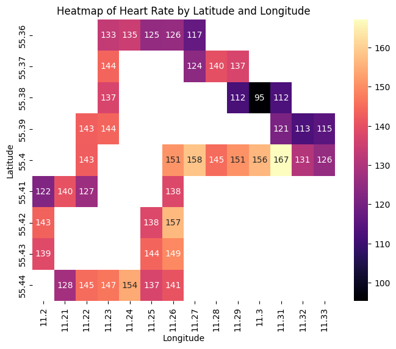

```python
# TODO: Plot Heatmap with longitude and latitude on the x and y axes, respectively, and color the points based on the Heart Rate.

USER_ID = 9633831
PALLETE_NAME = "magma"

filtered_hrr_df = endomondo_df[endomondo_df['id'] == USER_ID]
heatmap_hrr_df = filtered_df[['heart_rate','latitude','longitude']]

# Round latitude and longitude to reduce granularity
heatmap_hrr_df.loc[:,'latitude'] = heatmap_hrr_df['latitude'].round(2)
heatmap_hrr_df.loc[:,'longitude'] = heatmap_hrr_df['longitude'].round(2)

# Recreate the pivot table
data_pivot_hrr = heatmap_hrr_df.pivot_table(index='latitude', columns='longitude', values='heart_rate')


vmin = data_pivot_hrr.min().min()
vmax = data_pivot_hrr.max().max()

# Create the heatmap
plt.figure(figsize=(8, 6))
sns.heatmap(data_pivot_hrr, cmap=PALLETE_NAME, annot=True, fmt=".0f",cbar=True, vmin=vmin, vmax=vmax)

# Set axis labels and title
plt.xlabel('Longitude')
plt.ylabel('Latitude')
plt.title('Heatmap of Heart Rate by Latitude and Longitude')

# Show the plot
plt.show()
```

# Part 3: Modelling (Supervised Learning - Regression)

In this section, we are performing supervised learning techniques by building a regression model to predict changes in heart rate based on features extracted from a dataset of user workout records. There will be two linear regression models evaluated, which are single linear regression and multiple linear regression.

The steps involved in building and evaluating these regression models include:

1. **Feature Extraction**: Extract relevant features from the dataset, such as average speed, workout time, total distance, and other variables that may influence heart rate.
2. **Data Preprocessing**: Clean and preprocess the data to ensure it is suitable for modeling. This may involve handling missing values, normalizing features, and splitting the data into training and testing sets.
3. **Model Building**: Develop the single linear regression model using one feature and the multiple linear regression model using several features. Fit the models to the training data to learn the relationships between the features and heart rate changes.
4. **Model Evaluation**: Evaluate the performance of both models using appropriate metrics such as Mean Squared Error (MSE), R-squared, and others. Compare the results to determine which model provides better predictions.
5. **Interpretation and Insights**: Analyze the coefficients of the regression models to understand the impact of each feature on heart rate changes. Draw insights from the models to inform future workout recommendations and improvements.

## 3.1: Data Loading

For this part, we loaded the dataset generated from earlier section, namely `endomondo_proper_cleaned_expanded.csv` using pandas `read_csv` function. The loaded dataframe will be named as `endomondo_df`.

```python
CSV_FILE_NAME = "endomondo_proper_cleaned_expanded.csv"
endomondo_df = pd.read_csv(CSV_FILE_NAME)
```

## 3.2: Data Preperation and Feature Engineering

Creating Heart Rate, Speed, and Altitude Difference Features

In this section, three new features are going to be created, which are heart rate difference (`heart_rate_diff`), speed difference (`speed_diff`), and altitude difference (`altitude_diff`). To do this, we sort the data within `endomondo_df` by `id` first and then `timestamp` to maintain sequence of timing for each user. And then we calculate the difference between the current and the previous heart rate, speed, and altitude for each user, and add these differences to new columns named `heart_rate_diff`, `speed_diff`, and `altitude_diff` to the dataframe.

```python
# Compute the difference between consecutive heart rate, speed, and altitude values for each workout
endomondo_df = endomondo_df.sort_values(by=['id', 'timestamp'])
endomondo_df['heart_rate_diff'] = endomondo_df.groupby('id')['heart_rate'].diff()
endomondo_df['speed_diff'] = endomondo_df.groupby('id')['speed'].diff()
endomondo_df['altitude_diff'] =endomondo_df.groupby('id')['altitude'].diff()
```

**Creating Time Elapsed Feature**

To compute elapsed time, we first convert the `timestamp` column in the dataframe from `string` type to a `datetime` type to ease the computation for elapsed time. Once converted, we determine the smallest timestamp data for each user, stored in `min_timestamps` variable. The `time_elapsed` column in the dataframe is computed by first finding the time difference between the current time and the `min_timestamps` and then converting it into seconds by using `total_seconds()` function. Head of the dataframe is displayed to verify that the column has been added correctly.

```python
endomondo_df['timestamp'] = pd.to_datetime(endomondo_df['timestamp'], format='%Y-%m-%d %H:%M:%S')

min_timestamps = endomondo_df.groupby('id')['timestamp'].transform('min')

endomondo_df['time_elapsed'] = (endomondo_df['timestamp'] - min_timestamps).dt.total_seconds()
```

Display dataframe head and generate summary statistics.

```python
endomondo_df.head()
```

|  | id | latitude | longitude | altitude | timestamp | sport | speed | heart_rate | heart_rate_diff | speed_diff | altitude_diff | time_elapsed |
| --- | --- | --- | --- | --- | --- | --- | --- | --- | --- | --- | --- | --- |
| 825000 | 9633831.0 | 55.394735 | 11.320205 | 48.4 | 2011-04-24 19:11:23 | bike | 8.1936 | 79 | NaN | NaN | NaN | 0.0 |
| 825001 | 9633831.0 | 55.394901 | 11.320333 | 48.4 | 2011-04-24 19:11:29 | bike | 12.3552 | 80 | 1.0 | 4.1616 | 0.0 | 6.0 |
| 825002 | 9633831.0 | 55.395057 | 11.320335 | 48.4 | 2011-04-24 19:11:33 | bike | 15.5232 | 88 | 8.0 | 3.1680 | 0.0 | 10.0 |
| 825003 | 9633831.0 | 55.395301 | 11.320523 | 48.4 | 2011-04-24 19:11:40 | bike | 17.3952 | 92 | 4.0 | 1.8720 | 0.0 | 17.0 |
| 825004 | 9633831.0 | 55.395419 | 11.321237 | 48.4 | 2011-04-24 19:11:48 | bike | 22.9140 | 98 | 6.0 | 5.5188 | 0.0 | 25.0 |

```python
endomondo_df.describe()
```

|  | id | latitude | longitude | altitude | timestamp | speed | heart_rate | heart_rate_diff | speed_diff | altitude_diff | time_elapsed |
| --- | --- | --- | --- | --- | --- | --- | --- | --- | --- | --- | --- |
| count | 9.695500e+06 | 9.695500e+06 | 9.695500e+06 | 9.695500e+06 | 9695500 | 9.695500e+06 | 9.695500e+06 | 9.676109e+06 | 9.676109e+06 | 9.676109e+06 | 9.695500e+06 |
| mean | 4.149245e+08 | 4.310441e+01 | 1.268424e+01 | 1.589258e+02 | 2014-09-08 00:16:20.214210048 | 1.982974e+01 | 1.414848e+02 | 8.463846e-02 | 3.318267e-03 | -3.826745e-04 | 2.544486e+03 |
| min | 9.633831e+06 | -4.701251e+01 | -1.560338e+02 | -5.000000e+02 | 2011-01-01 01:56:59 | 3.240000e-02 | 3.200000e+01 | -7.000000e+01 | -2.250148e+02 | -9.500000e+02 | 0.000000e+00 |
| 25% | 3.222966e+08 | 3.889882e+01 | -5.287755e-01 | 2.980000e+01 | 2014-04-01 23:19:25.500000 | 1.128600e+01 | 1.290000e+02 | -1.000000e+00 | -5.040000e-01 | -4.000000e-01 | 8.790000e+02 |
| 50% | 4.229871e+08 | 5.027649e+01 | 1.122445e+01 | 7.640000e+01 | 2014-10-07 02:01:47 | 1.598040e+01 | 1.430000e+02 | 0.000000e+00 | 0.000000e+00 | 0.000000e+00 | 1.918000e+03 |
| 75% | 5.368053e+08 | 5.544339e+01 | 2.153465e+01 | 1.770000e+02 | 2015-05-31 20:02:11.249999872 | 2.777040e+01 | 1.560000e+02 | 1.000000e+00 | 5.652000e-01 | 4.000000e-01 | 3.385000e+03 |
| max | 6.692632e+08 | 6.788297e+01 | 1.773666e+02 | 9.305600e+03 | 2016-01-01 10:44:31 | 2.334640e+02 | 2.400000e+02 | 7.000000e+01 | 2.120108e+02 | 9.484000e+02 | 1.799900e+04 |
| std | 1.499498e+08 | 1.805986e+01 | 5.371942e+01 | 2.986308e+02 | NaN | 1.029736e+01 | 2.082399e+01 | 3.832334e+00 | 3.236159e+00 | 2.679891e+00 | 2.384596e+03 |

We now focus on a specific user with `id` number 396826535. We created a new dataframe named `user_df` by filtering the main `endomondo_df` dataframe. We display the tail of the `user_df` dataframe to verify the filtering.

```python
user_df = endomondo_df[endomondo_df['id'] == 396826535.0]
user_df.tail()
```

|  | id | latitude | longitude | altitude | timestamp | sport | speed | heart_rate | heart_rate_diff | speed_diff | altitude_diff | time_elapsed |
| --- | --- | --- | --- | --- | --- | --- | --- | --- | --- | --- | --- | --- |
| 495 | 396826535.0 | 60.172047 | 24.649638 | 28.6 | 2014-08-24 18:51:13 | bike | 15.6132 | 147 | 7.0 | -5.5944 | 0.8 | 7527.0 |
| 496 | 396826535.0 | 60.172326 | 24.650321 | 29.8 | 2014-08-24 18:51:24 | bike | 17.1936 | 152 | 5.0 | 1.5804 | 1.2 | 7538.0 |
| 497 | 396826535.0 | 60.172648 | 24.651084 | 31.8 | 2014-08-24 18:51:37 | bike | 14.4576 | 153 | 1.0 | -2.7360 | 2.0 | 7551.0 |
| 498 | 396826535.0 | 60.173104 | 24.650747 | 34.4 | 2014-08-24 18:51:51 | bike | 15.7104 | 163 | 10.0 | 1.2528 | 2.6 | 7565.0 |
| 499 | 396826535.0 | 60.173354 | 24.649666 | 36.2 | 2014-08-24 18:52:15 | bike | 3.8592 | 151 | -12.0 | -11.8512 | 1.8 | 7589.0 |

Handling NaN values

We therefore delete these rows as we believe that if we fill these values to 0 it will not be realistic as the user might be from resting position and their body are still warming up. Then, the number of rows dropped are relatively small compared to entire dataset (19391 rows with `NaN` and there are 9695500 rows)

```python
endomondo_df = endomondo_df.dropna()
endomondo_df.head()
```

|  | id | latitude | longitude | altitude | timestamp | sport | speed | heart_rate | heart_rate_diff | speed_diff | altitude_diff | time_elapsed |
| --- | --- | --- | --- | --- | --- | --- | --- | --- | --- | --- | --- | --- |
| 825001 | 9633831.0 | 55.394901 | 11.320333 | 48.4 | 2011-04-24 19:11:29 | bike | 12.3552 | 80 | 1.0 | 4.1616 | 0.0 | 6.0 |
| 825002 | 9633831.0 | 55.395057 | 11.320335 | 48.4 | 2011-04-24 19:11:33 | bike | 15.5232 | 88 | 8.0 | 3.1680 | 0.0 | 10.0 |
| 825003 | 9633831.0 | 55.395301 | 11.320523 | 48.4 | 2011-04-24 19:11:40 | bike | 17.3952 | 92 | 4.0 | 1.8720 | 0.0 | 17.0 |
| 825004 | 9633831.0 | 55.395419 | 11.321237 | 48.4 | 2011-04-24 19:11:48 | bike | 22.9140 | 98 | 6.0 | 5.5188 | 0.0 | 25.0 |
| 825005 | 9633831.0 | 55.395494 | 11.321969 | 48.4 | 2011-04-24 19:11:55 | bike | 25.0848 | 106 | 8.0 | 2.1708 | 0.0 | 32.0 |

We further verify that there are no rows with `NaN` values remaining.

```python
endomondo_df.isna().sum()
```

|  | 0 |
| --- | --- |
| id | 0 |
| latitude | 0 |
| longitude | 0 |
| altitude | 0 |
| timestamp | 0 |
| sport | 0 |
| speed | 0 |
| heart_rate | 0 |
| heart_rate_diff | 0 |
| speed_diff | 0 |
| altitude_diff | 0 |
| time_elapsed | 0 |

**dtype:** int64

## 3.3: Model Training and Application

For this section, we are going to evaluate single linear regression and multiple linear regression.

**Single Linear Regression**

Define the Features and Target Variable

- Features: 'Speed_diff'
- Target: 'Heart_rate_diff'

```python
X_Features = ["speed_diff"] # Features to use as input for the model
Y_Features = ["heart_rate_diff"] # Features to predict
TEST_SIZE = 0.0001
RANDOM_STATE = 42
```

Assign `x` and `y` values based on the `X_Features` and `Y_Features` provided.

```python
x = endomondo_df[X_Features]
y = endomondo_df[Y_Features]
```

**Training and Testing Data Splitting**

We split the training and testing datasets using `train_test_split` function from `sklearn` library, where it automatically divided the training and testing datasets based on the requirements. In this case, 0.01% of the data is used for model testing and the remaining data is used for model training. We then displayed the shapes for the training and testing datasets to verify the splitting is done properly.

```python
from sklearn.model_selection import train_test_split

X_train, X_test, y_train, y_test = train_test_split( x, y, test_size = TEST_SIZE , random_state= RANDOM_STATE)

# Display the resulting shapes of the splits
print("X_train shape:", X_train.shape)
print("X_test shape:", X_test.shape)
print("Y_train shape:", y_train.shape)
print("Y_test shape:", y_test.shape)
```

```
X_train shape: (9675141, 1)
X_test shape: (968, 1)
Y_train shape: (9675141, 1)
Y_test shape: (968, 1)
```

Model Training

To train the linear regression model, we use the `linear_model` package from the `sklearn` library. We defined `model` as a new linear regression model where the training datasets are being fitted into the model.

```python
import sklearn.linear_model

# Train the Linear Regression model
model = sklearn.linear_model.LinearRegression()
model.fit(X_train, y_train)
```

```
LinearRegression()
```

Model Testing (Prediction)

Once the model has been fitted, we can predict the output values based on our test dataset. This can be done by calling `predict` function on the `model` by passing in our `X_test` variable. The predicted values from the model is named as `Y_pred`. Once the prediction has been generated, we print the model coefficient and intercept.

```python
Y_pred = model.predict(X_test)

print("Model Coefficients:", model.coef_)
print("Model Intercept:", model.intercept_)
```

```
Model Coefficients: [[0.09488618]]
Model Intercept: [0.08432129]
```

## 3.4 Model Evaluation and Visualization

Computing Evaluation Parameters

We computed the Mean Squared Error (MSE) value using the built-in `mean_squared_error` function from the `sklearn.metrics` library. The values then printed for our reference.

```python
from sklearn.metrics import mean_squared_error
from sklearn.metrics import mean_absolute_error

mse = mean_squared_error(y_test, Y_pred)
mae = mean_absolute_error(y_test, Y_pred)
print("Mean Squared Error:", mse)
print("Mean Absolute Error:", mae)
```

```
Mean Squared Error: 14.144823176793047
Mean Absolute Error: 2.135089631566253
```

Calculate the Mean Absolute Error (MAE)

We computed the Mean Absolute Error (MAE) value using the built-in `mean_absolute_error` function from the `sklearn.metrics` library. The values then printed for our reference.

```python
from sklearn.metrics import mean_absolute_error

mae = mean_absolute_error(y_test, Y_pred)
print("Mean Absolute Error:", mae)
```

```
Mean Absolute Error: 2.135089631566253
```

Visualize the predicted vs actual heart rate changes

In this section, we created a scatterplot comparing the prediction of the linear regression model (marked in red) versus the reference value from the testing data (marked in blue). For the reference (actual values), we plot `y_test` (actual heart rate difference) against `X_test` (speed difference). For the model prediction values, we plot `Y_pred` (predicted heart rate difference) against `X_test` as well.

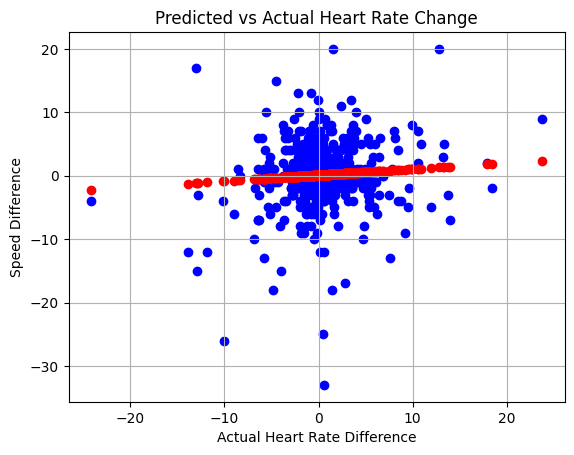

```python
plt.scatter(X_test, y_test, color='blue', label='Actual Values')

# Plot the predicted target values in red
plt.scatter(X_test, Y_pred, color='red', label='Predicted Values')

plt.title('Predicted vs Actual Heart Rate Change')
plt.xlabel('Actual Heart Rate Difference')
plt.ylabel('Speed Difference')
plt.grid(True)
plt.show()
```

## 3.5: Model Improvement with More Features (Multivariate Regression)

In order to improve the linear regression model further, we added `altitude_diff` as an additional feature in the `X_features` array.

```python
X_Features = ["speed_diff", "altitude_diff"] # Features to use as input for the model
Y_Features = ["heart_rate_diff"] # Features to predict
TEST_SIZE = 0.0001
RANDOM_STATE = 42
```

Check Correlation between Features

To check the correlation between `speed_diff` and `altitude_diff` features, we are plotting a correlation matrix. We create a new dataframe `X_Features_df` which contains the `speed_diff` and `altitude_diff` from the `endomondo_df` dataframe. We then create a correlation matrix `corr_matrix` by calling on the `corr()` function on the `X_features_df`. Once the correlation matrix is generated, we created a heatmap of the correlation matrix using `seaborn` package's `heatmap` function.

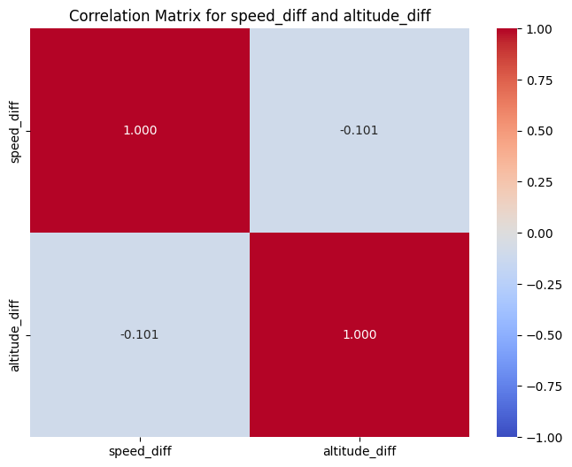

```python
X_Features_df = endomondo_df[["speed_diff", "altitude_diff"]]
Y_Features_df = endomondo_df["heart_rate_diff"]

# Compute the correlation matrix
corr_matrix = X_Features_df.corr()

# Plot the correlation matrix using seaborn
plt.figure(figsize=(8, 6))
sns.heatmap(corr_matrix, annot=True, cmap='coolwarm', fmt=".3f",vmin=-1, vmax=1, center=0)
plt.title("Correlation Matrix for speed_diff and altitude_diff")
plt.show()
```

Split the data into training and testing sets

Following the previous section, we again create the testing and training datasets using the `train_test_split` function.

```python
from sklearn.model_selection import train_test_split
X = endomondo_df[X_Features]
Y = endomondo_df[Y_Features]

# Split the data into training and testing sets using the full sklearn path
X_train, X_test, Y_train, Y_test = train_test_split(
    X, Y,
    test_size=TEST_SIZE,
    random_state=RANDOM_STATE
)

# Display the resulting shapes of the splits
print("X_train shape:", X_train.shape)
print("X_test shape:", X_test.shape)
print("Y_train shape:", Y_train.shape)
print("Y_test shape:", Y_test.shape)
```

```
X_train shape: (9675141, 2)
X_test shape: (968, 2)
Y_train shape: (9675141, 1)
Y_test shape: (968, 1)
```

Train a Linear Regression model

We run again the linear regression model with the updated `X_Features` which have altitude difference in addition to speed difference.

```python
from sklearn.linear_model import LinearRegression

model = LinearRegression()
model.fit(X_train, y_train)
```

```
LinearRegression()
```

Make predictions on the test set

```python
predictions = model.predict(X_test)
print("Model Coefficients:", model.coef_)

# To see the intercept (optional)
print("Model Intercept:", model.intercept_)
```

```
Model Coefficients: [[0.11164363 0.20122783]]
Model Intercept: [0.08434585]
```

Compute the Mean Squared Error (MSE)

We computed the Mean Squared Error (MSE) value using the built-in `mean_squared_error` function from the `sklearn.metrics` library. The values then printed for our reference.

```python
mse = mean_squared_error(y_test, predictions)
print("Mean Squared Error:", mse)
```

```
Mean Squared Error: 13.969779330984599
```

Compute the Mean Absolute Error (MSE)

We computed the Mean Absolute Error (MAE) value using the built-in `mean_absolute_error` function from the `sklearn.metrics` library. The values then printed for our reference.

```python
mae = mean_absolute_error(y_test, predictions)
print("Mean Absolute Error:", mae)
```

```
Mean Absolute Error: 2.130844095894468
```

Visualize the changes in heart rate predicted by the model

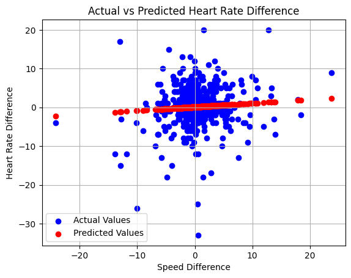

```python
# Plot the actual target values in blue
plt.scatter(X_test['speed_diff'], Y_test, color='blue', label='Actual Values')

# Plot the predicted target values in red
plt.scatter(X_test['speed_diff'], Y_pred, color='red', label='Predicted Values')

# Add labels and title
plt.xlabel('Speed Difference')
plt.ylabel('Heart Rate Difference')
plt.title('Actual vs Predicted Heart Rate Difference')
plt.grid(True)
plt.legend()
plt.show()
```

## 3.6: Model Comparison

Compare the performance of the models

Reason for why Multiple Linear Regression Model works better is because of the low correlation between speed and altitude and the fact that these 2 features do affect heart rate. This provides a better training model as compared to Linear Regression which is solely reliant on one feature (speed difference).

# Part 4: Modelling (Classification)

In this section, the report explores data modeling with unsupervised machine learning by using the K-means clustering method. K-means clustering is a popular algorithm used to partition a dataset into distinct groups or clusters based on feature similarity. This method is particularly useful for identifying patterns and structures within the data without prior knowledge of the labels.

The process begins by selecting the number of clusters (K) and initializing the cluster centroids. The algorithm then iteratively assigns each data point to the nearest centroid and updates the centroids based on the mean of the assigned points. This process continues until the centroids no longer change significantly, indicating that the clusters are stable.

In this part of the report, we will:

1. **Preprocess the Data**: Ensure the data is clean and normalized to improve the performance of the K-means algorithm.
2. **Determine the Optimal Number of Clusters**: Use methods such as the Elbow Method and Silhouette Analysis to identify the most appropriate number of clusters for our dataset.
3. **Apply K-means Clustering**: Implement the K-means algorithm on the preprocessed data and analyze the resulting clusters.
4. **Evaluate Cluster Quality**: Assess the quality of the clusters using metrics such as inertia, silhouette score, and visual inspection.
5. **Interpret the Results**: Understand the characteristics of each cluster and derive meaningful insights from the clustering results.

By the end of this section, we aim to uncover hidden patterns and groupings within the data, providing a deeper understanding of the underlying structure. This analysis will help inform subsequent steps in the project and contribute to the overall goal of enhancing user experience through intelligent data-driven insights.

## 4.1: Data Preprocessing

In this part, we perform some data preprocessing to ensure clean and normalized data are being used to the subsequent modeling steps.

We will be performing the following steps:

1. Filter Data for specific sport
2. Generate Average Speed Dataset
3. Compute Total Workout Time
4. Compute Total Distance Covered
5. Merge the datasets together

**4.1.1. Filter Data for Specific Sport**

We start off by filtering the dataset to include only users participating in the sport Bike. We choose `Bike` sport to allow us to simplify the modeling application to just one type of feature set.

We first compare the amount of rows available before and after the filtering and from that we shaved off about 53% of the overall datasets

```python
endomondo_df.head()
endomondo_df.shape
```

```
(9676109, 12)
```

```python
# Filter sport that participate in bike
bike_df = endomondo_df[endomondo_df['sport'] == 'bike']
bike_df.head()
```

|  | id | latitude | longitude | altitude | timestamp | sport | speed | heart_rate | heart_rate_diff | speed_diff | altitude_diff | time_elapsed |
| --- | --- | --- | --- | --- | --- | --- | --- | --- | --- | --- | --- | --- |
| 825001 | 9633831.0 | 55.394901 | 11.320333 | 48.4 | 2011-04-24 19:11:29 | bike | 12.3552 | 80 | 1.0 | 4.1616 | 0.0 | 6.0 |
| 825002 | 9633831.0 | 55.395057 | 11.320335 | 48.4 | 2011-04-24 19:11:33 | bike | 15.5232 | 88 | 8.0 | 3.1680 | 0.0 | 10.0 |
| 825003 | 9633831.0 | 55.395301 | 11.320523 | 48.4 | 2011-04-24 19:11:40 | bike | 17.3952 | 92 | 4.0 | 1.8720 | 0.0 | 17.0 |
| 825004 | 9633831.0 | 55.395419 | 11.321237 | 48.4 | 2011-04-24 19:11:48 | bike | 22.9140 | 98 | 6.0 | 5.5188 | 0.0 | 25.0 |
| 825005 | 9633831.0 | 55.395494 | 11.321969 | 48.4 | 2011-04-24 19:11:55 | bike | 25.0848 | 106 | 8.0 | 2.1708 | 0.0 | 32.0 |

```python
bike_df.shape
```

```
(4569842, 12)
```

**4.1.2. Generate Average Speed Dataset**

In order to obtain a more representative value of the speed by average. we create a new dataset with `user_ids` and their average speed `avg_speed`

```python
avg_speed = bike_df.groupby('id')['speed'].mean()
avg_speed_df = pd.DataFrame({'user_id': avg_speed.index, 'avg_speed': avg_speed.values})
avg_speed_df.head()
```

|  | user_id | avg_speed |
| --- | --- | --- |
| 0 | 9633831.0 | 29.922911 |
| 1 | 10544802.0 | 29.879185 |
| 2 | 11426022.0 | 25.114812 |
| 3 | 11639926.0 | 24.451792 |
| 4 | 11908018.0 | 30.857916 |

**4.1.3. Compute Total Workout Time**

In this step, we aim to compute the total workout time for each user. This involves creating a new dataset that includes user IDs and their corresponding total workout time, referred to as `workout_time`. The total workout time is calculated as the difference between the minimum and maximum timestamps recorded for each user, measured in seconds.

To achieve this, we will:

1. **Extract Timestamps**: Identify and extract the timestamp data for each user from the dataset.
2. **Calculate Time Difference**: For each user, compute the difference between the maximum and minimum timestamps. This difference represents the total duration of the workout session in seconds.
3. **Create New Dataset**: Construct a new dataset that includes each user's ID and their calculated total workout time.
4. **Verify Results**: Ensure the accuracy of the computed workout times by performing sanity checks and validating against known data points.

By computing the total workout time, we gain valuable insights into the duration of each user's physical activities.

```python
min_time = bike_df.groupby('id')['timestamp'].min()
max_time = bike_df.groupby('id')['timestamp'].max()

total_time = max_time - min_time
total_time = total_time.dt.total_seconds()
workout_time_df = pd.DataFrame({'user_id': total_time.index, 'workout_time': total_time.values})
workout_time_df.head()
```

|  | user_id | workout_time |
| --- | --- | --- |
| 0 | 9633831.0 | 4894.0 |
| 1 | 10544802.0 | 4603.0 |
| 2 | 11426022.0 | 7686.0 |
| 3 | 11639926.0 | 8874.0 |
| 4 | 11908018.0 | 11027.0 |

**4.1.4. Compute Total Distance Covered**

In this part, we aim to compute the total distance covered by each user during their workout sessions. This involves creating a new dataset that includes `user_ids` and the corresponding total distance, referred to as `total_distance`, covered by each user. The total distance is calculated by summing up the distances recorded at each timestamp for each user.

To achieve this, we will:

1. **Extract Distance Data**: Identify and extract the distance data for each user from the dataset. This data typically includes the distance covered at each recorded timestamp.
2. **Calculate Total Distance**: For each user, sum up the distances recorded at each timestamp to compute the total distance covered during their workout sessions.
3. **Create New Dataset**: Construct a new dataset that includes each user's ID and their calculated total distance covered.
4. **Verify Results**: Ensure the accuracy of the computed total distances by performing sanity checks and validating against known data points.

By computing the total distance covered, we gain valuable insights into the extent of each user's physical activities. This information can be used for further analysis, such as identifying patterns in distance covered, comparing activity levels among users, and enhancing personalized recommendations. This step is crucial for understanding user behavior and improving the overall effectiveness of the fitness tracking application.

```python
#calculate the total distance by multiplying the time_elapsed with speed and summing them together per id
total_distance = bike_df.groupby('id').apply(lambda x: (x['time_elapsed'] * x['speed']/1000).sum()) #change to KM
total_distance_df = pd.DataFrame({'user_id': total_distance.index, 'total_distance': total_distance.values})
total_distance_df.head()
```

|  | user_id | total_distance |
| --- | --- | --- |
| 0 | 9633831.0 | 34688.363191 |
| 1 | 10544802.0 | 31733.564033 |
| 2 | 11426022.0 | 59206.483804 |
| 3 | 11639926.0 | 58450.955972 |
| 4 | 11908018.0 | 87261.134666 |

**4.1.5. Merge Processed Data**

In this part, we merge all the above datasets (`avg_speed_df`, `workout_time_df`, `user_merged_df` and `total_distance_df`) into a single data frame called `user_merged_df`

```python
user_merged_df = pd.merge(avg_speed_df, workout_time_df, on='user_id')
user_merged_df = pd.merge(user_merged_df, total_distance_df, on='user_id')
user_merged_df.head()
```

|  | user_id | avg_speed | workout_time | total_distance |
| --- | --- | --- | --- | --- |
| 0 | 9633831.0 | 29.922911 | 4894.0 | 34688.363191 |
| 1 | 10544802.0 | 29.879185 | 4603.0 | 31733.564033 |
| 2 | 11426022.0 | 25.114812 | 7686.0 | 59206.483804 |
| 3 | 11639926.0 | 24.451792 | 8874.0 | 58450.955972 |
| 4 | 11908018.0 | 30.857916 | 11027.0 | 87261.134666 |

## 4.2: Determine the Optimal Number of Clusters

Determining the optimal number of clusters is a crucial step in the K-means clustering process. The goal is to identify the number of clusters that best represents the underlying structure of the data.

We will be doing the following steps:

1. Run K-Means for Different Cluster Numbers
2. Elbow Method for Optimal Clusters
3. Cluster Analysis and Visualization
4. Visualize the Clusters

**4.2.1. Run K-Means for Different Cluster Numbers**

In this step, we will use the `user_merged_df` dataset to run K-means clustering with a range of cluster numbers, specifically from 2 to 11 clusters. For each run, we will calculate the inertia of the clusters.

This analysis is essential for ensuring that our clustering model accurately captures the natural groupings within the data, leading to more meaningful and actionable insights.

```python
from sklearn.cluster import KMeans
from collections import defaultdict
inertia = defaultdict(int)

# Run K-Means for cluster numbers from 2 to 11
for n_clusters in range(2, 12):
    kmeans = KMeans(n_clusters=n_clusters, random_state=42)
    # Using all numerical features for clustering
    kmeans.fit(user_merged_df[['avg_speed', 'workout_time', 'total_distance']])
    # Append the inertia value for the current number of cluster
    inertia[n_clusters] = kmeans.inertia_
```

**4.2.2. Elbow Method for Optimal Clusters**

The Elbow Method is a widely used technique for determining the optimal number of clusters in K-means clustering. It involves plotting the inertia values against the number of clusters to visually identify the point where adding more clusters yields diminishing returns in terms of reducing inertia.

- Plotting Inertia: First, we plot the inertia (y-axis) against the number of clusters (x-axis) for the range of cluster numbers we tested (from 2 to 11). Each point on the plot represents the inertia value for a specific number of clusters.
- Interpretting the Elbow plot: The Elbow Method helps in selecting the number of clusters by identifying where the inertia starts to decrease more slowly.
- Choosing the Optimal Number of Clusters: Based on the Elbow plot, we choose the optimal number of clusters of 4. This is the point where the inertia curve bends and starts to flatten out. Selecting this number of clusters ensures that we have a good balance between having compact clusters and not overfitting the data with too many clusters.

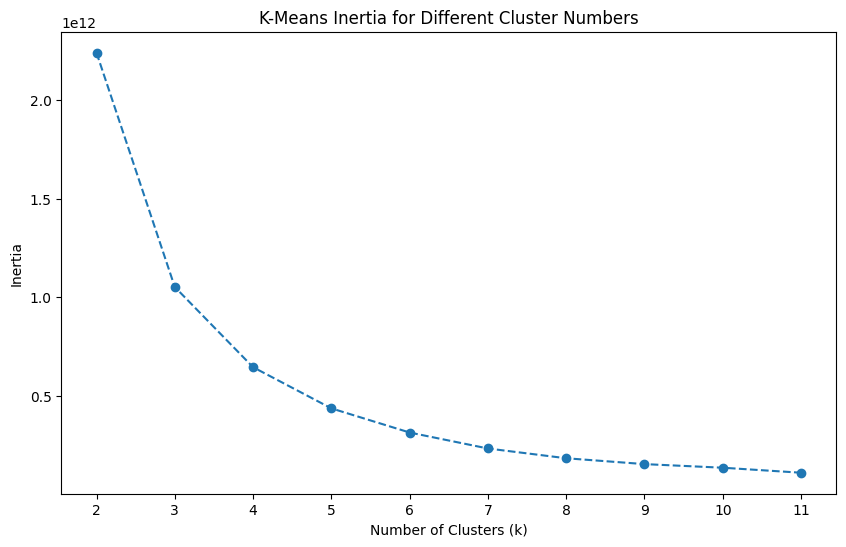

```python
#Plot using inertia for elbow method
plt.figure(figsize=(10, 6))
plt.plot(inertia.keys(), inertia.values(), marker='o', linestyle='--')

#increase markers
plt.xticks(range(2, 12))

plt.title('K-Means Inertia for Different Cluster Numbers')
plt.xlabel('Number of Clusters (k)')
plt.ylabel('Inertia')
plt.show()
```

From the inertia values:

- The drop is significant from k = 2 to k = 3, and then the rate of decrease slows down.
- Between k = 4 to k = 11, there is significantly less reduction

Based on the elbow method, k = 4 is the best number of clusters.

## 4.3: Cluster Visualization & Analysis

In this section, we will be performing the following:

1. Identify the Cluster Number for each User
2. Visualizing the Clusters

**4.3.1. Cluster Analysis and Visualization**

- Identify the Cluster Number for Each User
  - In this step, we will create a K-means model using the features from user_merged_df and the optimal number of clusters identified in Part 2.
  - Once the model is trained, we will assign each user to a cluster and add a new column called cluster to the DataFrame, which contains the cluster number for each user. This allows us to analyze and visualize the grouping of users based on their activity data.

```python
# Create k means model using features and k = 4
kmeans = KMeans(n_clusters=4, random_state=42)
kmeans.fit(user_merged_df[['avg_speed', 'workout_time', 'total_distance']])

# Add a new column to the data frame called cluster that contains the cluster number for each user
user_merged_df['cluster'] = kmeans.labels_
user_merged_df.head()
```

|  | user_id | avg_speed | workout_time | total_distance | cluster |
| --- | --- | --- | --- | --- | --- |
| 0 | 9633831.0 | 29.922911 | 4894.0 | 34688.363191 | 1 |
| 1 | 10544802.0 | 29.879185 | 4603.0 | 31733.564033 | 1 |
| 2 | 11426022.0 | 25.114812 | 7686.0 | 59206.483804 | 3 |
| 3 | 11639926.0 | 24.451792 | 8874.0 | 58450.955972 | 3 |
| 4 | 11908018.0 | 30.857916 | 11027.0 | 87261.134666 | 0 |

**4.3.2. Visualize the Clusters**

Visualizing the clusters is a crucial step in understanding the grouping of users based on their activity data. We use a scatter plot to represent the clusters, which allows us to see how users are distributed across different clusters.

Given the number of features we are using—average speed, workout time, and total distance. We expand the scatter plot representation into a 3D space. This 3D scatter plot will provide a more comprehensive view of the clusters, enabling us to appreciate the relationships between these features and how they contribute to the clustering.

To create the 3D scatter plot, we will:

1. Plot the Clusters: Use the three features (average speed, workout time, and total distance) as the axes of the 3D scatter plot. Each point in the plot will represent a user, colored according to their assigned cluster.
2. Enhance Visualization: Consider using dimensionality reduction techniques like Principal Component Analysis (PCA) or t-SNE if necessary. These techniques can help reduce the complexity of the data while preserving the relationships between points, making the clusters easier to visualize and interpret.

By visualizing the clusters in 3D space, we gain a better understanding of the distribution and separation of users based on their activity data. This visualization also sets the stage for applying dimensionality reduction techniques, which can further enhance our ability to interpret and analyze the clustering results.

*4.3.2.1 3D Scatter plot with all 3 features*

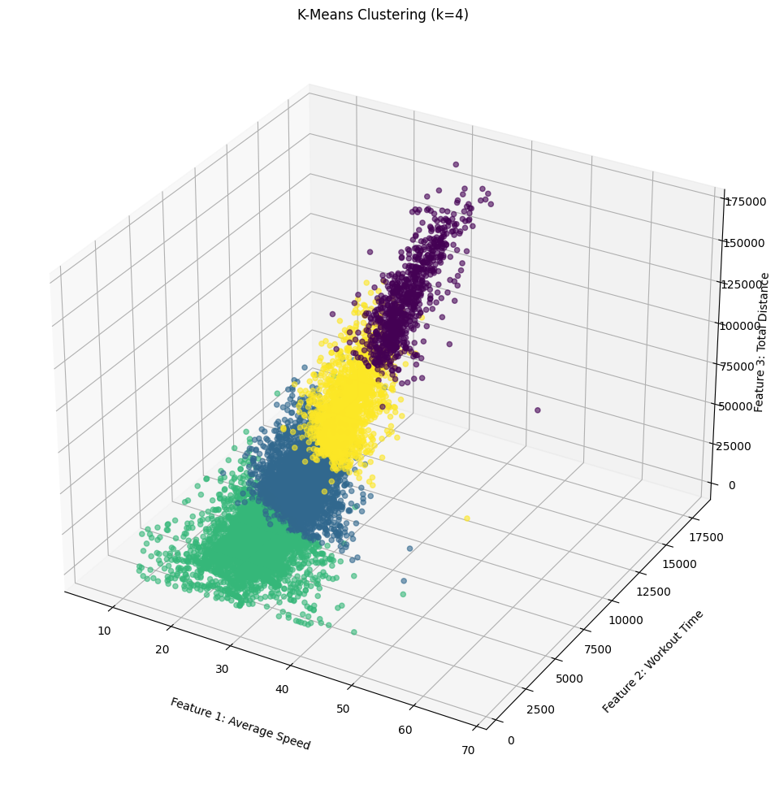

```python
#3D plot with original features

from mpl_toolkits.mplot3d import Axes3D

# Prepare for 3D visualization
fig = plt.figure(figsize=(12, 12))
ax = fig.add_subplot(111, projection='3d')

# Scatter plot
scatter = ax.scatter(user_merged_df.iloc[:, 1], user_merged_df.iloc[:, 2], user_merged_df.iloc[:, 3],
                     c=kmeans.labels_, cmap='viridis', marker='o', alpha=0.6)

# Add titles and labels
ax.set_title('K-Means Clustering (k=4)')
ax.set_xlabel('Feature 1: Average Speed',labelpad = 20)
ax.set_ylabel('Feature 2: Workout Time',labelpad = 20)
ax.set_zlabel('Feature 3: Total Distance')

plt.show()
```

*4.3.2.2 PCA Plot*

In this section we explore the usage of dimensionality reduction technique with PCA, this technique transforms the data into a new coordinate system. The new axes (principal components) are linear combinations of the original features, ordered by the amount of variance they capture from the data. PCA helps in reducing the complexity of the data while preserving the most important information, making it easier to visualize and interpret.

In this part we will follow steps below:

- Feature selection: Before applying PCA, we select the features that will be deployed to PCA
- PCA Initialization and fitting: in this step, we specify the number of components to be reduced to. Then, we fit the features into the PCA model
- PCA transform: we use the transform function to process the features data and obtain the results with the reduced dimensions
- Plot the Transformed Data: Create a scatter plot using the transformed data. Each point represents a user, colored according to their assigned cluster.

```
Explained Variance Ratio: [0.99778907 0.00221092]
Total Explained Variance: 0.9999999872327634
```

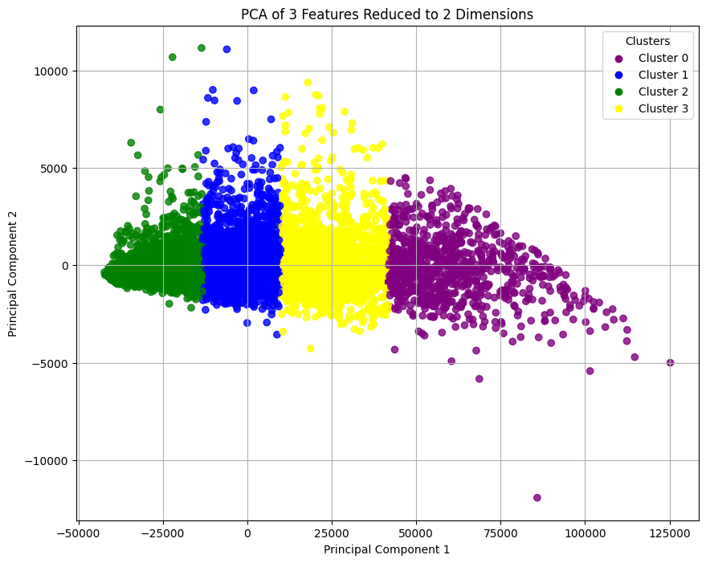

```python
# Plot for PCA

from sklearn.decomposition import PCA

# Select the features you want to reduce
features = user_merged_df.iloc[:, 1:4]  # Adjust indices based on your DataFrame structure

# Initialize PCA
pca = PCA(n_components=2)

# Fit PCA
pca.fit(features)

# Transform the data
pca_result = pca.transform(features)

# Explained variance ratio
explained_variance = pca.explained_variance_ratio_

print(f'Explained Variance Ratio: {explained_variance}')
print(f'Total Explained Variance: {sum(explained_variance)}')

# Create a DataFrame with the PCA results
pca_df = pd.DataFrame(data=pca_result, columns=['PC1', 'PC2'])


# Define a list of colors for each cluster
colors = ['purple', 'blue', 'green', 'yellow']
# Map each label to a color
assigned_colors = [colors[label] for label in kmeans.labels_]

# Visualize the PCA results with a scatter plot
plt.figure(figsize=(10, 8))
plt.scatter(pca_df['PC1'], pca_df['PC2'], c= assigned_colors, alpha=0.8)

plt.title('PCA of 3 Features Reduced to 2 Dimensions')

plt.xlabel('Principal Component 1')
plt.ylabel('Principal Component 2')

# Create a legend for clusters
unique_labels = set(kmeans.labels_)
for label in unique_labels:
    plt.scatter([], [], c=colors[label], label=f'Cluster {label}')  # Empty scatter for legend

plt.legend(title='Clusters')
plt.grid()
plt.show()
```

If your features are more than 10, t-SNE can help visualize complex relationships and cluster structures in lower dimensions. As we only have 3 features, we can ignore this plot

## 4.4 Identify Similar Users

In this step we identify the clusters of where the given `user_id` belongs to based on the cluster modeling obtained in the previous section.

In order to identify, we just perform slice-and-dice the `cluster` columns and rows based on the `user_id`.

As result, we get that the `user_id` -- 377398220 belongs to Cluster 2 and the list of dataset belonging to that user_id is being shown.

```python
# Identify with cluster the user Id belong to
user_id = 377398220
user_cluster = user_merged_df[user_merged_df['user_id'] == user_id]['cluster'].values[0]

print('User Id: 377398220 belongs to Cluster ',user_cluster)

workout_buddies = user_merged_df[user_merged_df['cluster']==user_cluster]['user_id'].reset_index(drop=True)
workout_buddies
```

```
User Id: 377398220 belongs to Cluster  2
```

|  | user_id |
| --- | --- |
| 0 | 13821125.0 |
| 1 | 13841976.0 |
| 2 | 13841978.0 |
| 3 | 14150160.0 |
| 4 | 14150166.0 |
| ... | ... |
| 3551 | 659391232.0 |
| 3552 | 659391259.0 |
| 3553 | 659391583.0 |
| 3554 | 659392035.0 |
| 3555 | 659392443.0 |

3556 rows × 1 columns

**dtype:** float64

# Part 5: Free-form Exploration

## 5.1: Problem definition

- Describe the analysis task and explain how the dataset supports the task.
- Identify the additional preprocessing to be done, if any.

**Context:**

Often, smartwatches are able to automatically detect that a user is engaging in a workout after a certain period of time. Example: Samsung Gear 4 automatically detects a workout after 10 minutes. However, the sport is labelled as "automatic workout" or similar. This means that sport specific analysis such as split laps, route travelled, max VO2 and more are not activated.

Our exploration looks into the possibility of identifying the sport that a user is engaging in within the first minute (60seconds) so that advanced analytics can be captured for the user automatically and improve user experience.

**Problem statement:**

Given the user's speed, altitude, latitude, longitude and time elapsed data, develop a model to label what sport the user is engaging in.

**Model selection**:

Several classification models including but not limited to Multinomial classifier and k-means clustering were initially under consideration. Multinomial was rejected as we are not confident in the required underlying assumption of linearity in the relation between the dependent variable (sport) and independent variables (speed, latitude, longitude, etc.)

Random Forest Classifier was eventually chosen due to higher performance expected from ensemble models as opposed to a single decision tree.

**Approach:**

1. Preprocessing
- filter dataset to only contain the first 60seconds of data per user
- filter out sports with < n=50 due to insufficient data for a robust classifier
- genreate the list of unique userIds and split the dataset by userIds into train and test sets with a 80:20 ratio
- For each row of data, lookup if the userId falls into test or train set to prepare the test and train sets accordingly
1. Feature Selection
- Generate a Correlation Matrix to ensure independence for each feature.
- Run a model of the training dataset to ascertain feature importance
1. Modelling
- Run model of Random Forest with features selected in (2)
1. Evaluate Performance Metrics:
- Confusion Matrix
- Accuracy, Precision, Recall

## 5.2: Solution

- Work towards solving the problem defined above.
- You should explain the steps involved in solving the problem along with the reasoning.

```python
from sklearn.preprocessing import LabelEncoder, StandardScaler
from sklearn.ensemble import RandomForestClassifier
from sklearn.model_selection import train_test_split
from sklearn.metrics import classification_report
from sklearn.preprocessing import OneHotEncoder
```

### 5.2.1 Preprocessing of dataset

For the preprocessing of the dataset, we will perform the following steps:

1. Create a copy of the preprocessed dataframe
2. Drop the following fields and sort the dataframe:
   - heart_rate_diff
   - speed_diff
   - altitude_diff
   - timestamp
3. Filter the dataframe to obtain the first 60 seconds of the user's activity
4. Check the number of users per sport
5. Drop any sport that has less than 50 users

Step 1: Create a copy of the preprocessed dataframe

- It is important to create a copy to ensure we do not affect the original dataframe

```python
#Create a copy of the preprocessed dataframe
copy_df = endomondo_df.copy()
copy_df.head()
```

|  | id | latitude | longitude | altitude | timestamp | sport | speed | heart_rate | heart_rate_diff | speed_diff | altitude_diff | time_elapsed |
| --- | --- | --- | --- | --- | --- | --- | --- | --- | --- | --- | --- | --- |
| 825001 | 9633831.0 | 55.394901 | 11.320333 | 48.4 | 2011-04-24 19:11:29 | bike | 12.3552 | 80 | 1.0 | 4.1616 | 0.0 | 6.0 |
| 825002 | 9633831.0 | 55.395057 | 11.320335 | 48.4 | 2011-04-24 19:11:33 | bike | 15.5232 | 88 | 8.0 | 3.1680 | 0.0 | 10.0 |
| 825003 | 9633831.0 | 55.395301 | 11.320523 | 48.4 | 2011-04-24 19:11:40 | bike | 17.3952 | 92 | 4.0 | 1.8720 | 0.0 | 17.0 |
| 825004 | 9633831.0 | 55.395419 | 11.321237 | 48.4 | 2011-04-24 19:11:48 | bike | 22.9140 | 98 | 6.0 | 5.5188 | 0.0 | 25.0 |
| 825005 | 9633831.0 | 55.395494 | 11.321969 | 48.4 | 2011-04-24 19:11:55 | bike | 25.0848 | 106 | 8.0 | 2.1708 | 0.0 | 32.0 |

Step 2: Drop some redundant columns and sort the dataframe

```python
#drop timestamp, heart_rate_diff, speed_diff,altitude_diff and id
copy_df = copy_df.drop(['heart_rate_diff', 'speed_diff', 'altitude_diff','timestamp'], axis=1)

# sort the dataframe
copy_df = copy_df.sort_values(by=['id', 'time_elapsed']).reset_index(drop=True)
```

Step 3 :Filter the dataframe to obtain the first 60 seconds of the user's activity

- Finally, we will now obtain the first 60 seconds of each user's activity. This will be our preprocessed dataframe for modelling the predicition of sport activity within the first 60 seconds

```python
# Filter data to include at least the first 60 seconds per user
def select_rows(group):
    idx = group[group['time_elapsed'] >= 60].index
    if not idx.empty:
        max_idx = idx[0]
        return group.loc[:max_idx]
    else:
        return group

df_filtered = copy_df.groupby('id', group_keys=False).apply(select_rows)

# Reset the index of the filtered DataFrame
df_filtered = df_filtered.reset_index(drop=True)
df_filtered.head()
```

|  | id | latitude | longitude | altitude | sport | speed | heart_rate | time_elapsed |
| --- | --- | --- | --- | --- | --- | --- | --- | --- |
| 0 | 9633831.0 | 55.394901 | 11.320333 | 48.4 | bike | 12.3552 | 80 | 6.0 |
| 1 | 9633831.0 | 55.395057 | 11.320335 | 48.4 | bike | 15.5232 | 88 | 10.0 |
| 2 | 9633831.0 | 55.395301 | 11.320523 | 48.4 | bike | 17.3952 | 92 | 17.0 |
| 3 | 9633831.0 | 55.395419 | 11.321237 | 48.4 | bike | 22.9140 | 98 | 25.0 |
| 4 | 9633831.0 | 55.395494 | 11.321969 | 48.4 | bike | 25.0848 | 106 | 32.0 |

Step 4: Check the number of users per sport

We will now check the distribution of users for each sport

```python
# Filter dataset based on sport and id
unique_ids_per_sport = df_filtered.groupby('sport')['id'].nunique().reset_index()

# Renaming columns for clarity
unique_ids_per_sport.columns = ['sport', 'unique_user_count']

# Display the result
print(unique_ids_per_sport)
```

```
                      sport  unique_user_count
0                      bike               9158
1          bike (transport)                643
2   core stability training                 14
3      cross-country skiing                 16
4           fitness walking                 25
5                    hiking                  3
6            indoor cycling                403
7                  kayaking                  3
8             mountain bike                524
9              orienteering                  7
10            roller skiing                 13
11                      run               8513
12                    skate                  9
13                     walk                 60
```

Step 5: Drop any sports that has less than 50 users

As we can see from the result above, the following sports have less than 50 users:

- core stability training
- cross-country skiing
- fitness walking
- hiking
- kayaking
- orienteering
- roller skiing
- skate

As these sports have very little data representation, we will be dropping them from our analysis

```python
# List of sports to drop
sports_to_drop = [
    'core stability training',
    'cross-country skiing',
    'fitness walking',
    'hiking',
    'kayaking',
    'orienteering',
    'roller skiing',
    'skate'
]

# Drop the specified sports from the DataFrame
df_filtered = df_filtered[~df_filtered['sport'].isin(sports_to_drop)]

# Optionally, reset the index after dropping rows
df_filtered.reset_index(drop=True, inplace=True)

#check unique sports in df_filtered
df_filtered['sport'].unique()
```

```
array(['bike', 'run', 'mountain bike', 'bike (transport)',
       'indoor cycling', 'walk'], dtype=object)
```

### 5.2.2 Splitting of dataset into Training and Testing

To split the dataset into training and testing, we will doing the following steps:

1. Create a mapping between users and sports
2. Do a stratified split based on User IDs and sports
3. Create the training and testing dataset based on the User IDs
4. Do a sanity check
5. Do standardization for integer values and one hot encoding for nominal values for both train and test dataset

Step 1: Create a Mapping Between Users and Sports

- Each user (i.e., each id) should be associated with one sport type. Achieve this by grouping your data by user and then assigning the most frequent sport for each user.

```python
# Group by user id and get the most frequent sport for each user
user_sport_mapping = df_filtered.groupby('id')['sport'].agg(lambda x: x.value_counts().idxmax()).reset_index()

# Rename columns for clarity
user_sport_mapping.columns = ['id', 'sport']
```

Step 2: Stratified Split Based on User IDs and Sport

- Next, perform the stratified split on the user level so that the same user’s data does not end up in both the training and test sets:

```python
# Stratified split on the user level based on the sport
train_users, test_users = train_test_split(
    user_sport_mapping['id'], test_size=0.2, random_state=42, stratify=user_sport_mapping['sport']
)
```

Step 3: Create Training and Test Sets Based on User IDs Now, filter the original dataset to get the rows corresponding to the train and test users

```python
# Create the training set: filter the original dataset based on train_users
train_df = df_filtered[df_filtered['id'].isin(train_users)]

# Create the test set: filter the original dataset based on test_users
test_df = df_filtered[df_filtered['id'].isin(test_users)]
```

Step 4: Validate the Split

- Finally, check that both the training and testing datasets have all 6 sports and also check the distribution:

```python
# Check the number of unique sports in both sets
print(train_df['sport'].nunique())  # Should return 6
print(test_df['sport'].nunique())  # Should return 6

# Check the distribution of sports in both sets
print('sport train',train_df['sport'].value_counts())
print('sport test',test_df['sport'].value_counts())
```

```
6
6
sport train sport
run                 92344
bike                62580
bike (transport)     6823
indoor cycling       3401
mountain bike        3228
walk                  612
Name: count, dtype: int64
sport test sport
run                 23019
bike                15253
bike (transport)     1732
mountain bike         849
indoor cycling        848
walk                  173
Name: count, dtype: int64
```

Step 5: Do standardization for integer values and one hot encoding for nominal values for both training and testing dataset

```python
# Make sure train_df_copy and test_df_copy are independent copies
train_df_copy = train_df.copy()
test_df_copy = test_df.copy()

# Encoding the 'sport' column
label_encoder = LabelEncoder()
train_df_copy['sport_encoded'] = label_encoder.fit_transform(train_df_copy['sport'])
test_df_copy['sport_encoded'] = label_encoder.transform(test_df_copy['sport'])

# Ensure numerical features are cast to float before scaling
features_to_scale = ['latitude', 'longitude', 'altitude', 'speed', 'heart_rate', 'time_elapsed']

# Convert columns to float type to avoid FutureWarning
train_df_copy[features_to_scale] = train_df_copy[features_to_scale].astype(float)
test_df_copy[features_to_scale] = test_df_copy[features_to_scale].astype(float)

# Scaling numerical features
scaler = StandardScaler()
train_df_copy[features_to_scale] = scaler.fit_transform(train_df_copy[features_to_scale])
test_df_copy[features_to_scale] = scaler.transform(test_df_copy[features_to_scale])

# Splitting the data into features (X) and target (y)
X_train = train_df_copy[['id'] + features_to_scale]
y_train = train_df_copy['sport_encoded']
X_test = test_df_copy[['id'] + features_to_scale]
y_test = test_df_copy['sport_encoded']


# Print the classes to confirm encoding
print(label_encoder.classes_)
```

```
['bike' 'bike (transport)' 'indoor cycling' 'mountain bike' 'run' 'walk']
```

```python
X_train.head()
```

|  | id | latitude | longitude | altitude | speed | heart_rate | time_elapsed |
| --- | --- | --- | --- | --- | --- | --- | --- |
| 0 | 9633831.0 | 0.637283 | 0.005168 | -0.337842 | -0.390300 | -1.535822 | -1.040256 |
| 1 | 9633831.0 | 0.637292 | 0.005168 | -0.337842 | -0.009270 | -1.190374 | -0.881021 |
| 2 | 9633831.0 | 0.637306 | 0.005172 | -0.337842 | 0.215885 | -1.017651 | -0.602359 |
| 3 | 9633831.0 | 0.637313 | 0.005185 | -0.337842 | 0.879658 | -0.758565 | -0.283888 |
| 4 | 9633831.0 | 0.637317 | 0.005199 | -0.337842 | 1.140750 | -0.413117 | -0.005225 |

### 5.2.3 Feature Selection

For Feature Selection, we will be using our Training Dataset Only.

We will be using the below strategies:

1. Correlation Matrix to check for any dependencies
2. Do RandomForest Modelling to check for feature importance in prediciting Sport label

Step 1: Correlation Matrix

Below, we will be doing a correlation matrix among the features to check for linear dependency

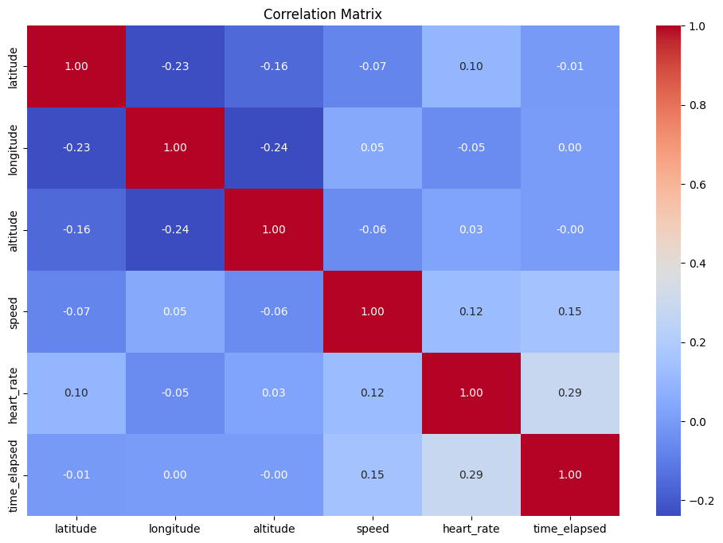

```python
#Feature Correlation
import seaborn as sns
import matplotlib.pyplot as plt

# List of features to include in the correlation matrix
features_to_scale = ['latitude', 'longitude', 'altitude', 'speed', 'heart_rate', 'time_elapsed']

# Subset the DataFrame to include only the selected features
df_subset = X_train[features_to_scale]

# One-hot encode the 'sport' column (and other categorical columns if necessary)
#df_encoded = pd.get_dummies(df_subset, columns=['sport'], drop_first=False)


# Compute the correlation matrix
corr_matrix = df_subset.corr()

# Display the correlation matrix
plt.figure(figsize=(12, 8))
sns.heatmap(corr_matrix, annot=True, cmap='coolwarm', fmt='.2f')
plt.title('Correlation Matrix')
plt.show()
```

Great, from above in our correlation matrix there are no features who have a correlation with one another

Step 2: Using RandomForestClassifier on the training dataset, we will be obtaining feature importance in prediciting sport label

```python
# Drop the 'id' column for training
X_train_no_id = X_train.drop('id', axis=1)

# Train the Random Forest model
rf = RandomForestClassifier(n_estimators=100, random_state=42)
rf.fit(X_train_no_id, y_train)

# Get feature importances
feature_importances = rf.feature_importances_

# Create a DataFrame for better visualization
feature_importance_df = pd.DataFrame({
    'Feature': X_train_no_id.columns,
    'Importance': feature_importances
})

# Sort the DataFrame by importance
feature_importance_df = feature_importance_df.sort_values(by='Importance', ascending=False)

# Print feature importances
print(feature_importance_df)
```

```
        Feature  Importance
3         speed    0.436400
1     longitude    0.215702
0      latitude    0.164143
2      altitude    0.075835
4    heart_rate    0.067698
5  time_elapsed    0.040222
```

From the results above, we can see that our top 4 features are speed, longtitude, latitude and altitude. We will be using these 4 features for our modelling.

### 5.2.4 Modelling

For Modelling, we will be doing the following steps:

1. We will drop heart_rate and time_elapsed form both train and test data
2. Run RandomForestClassifier on training dataset again with new features
3. With our model, predict the sport labels from our test data

Step 1: Drop redundant features from modelling

```python
#drop heart_rate and time_elapsed from train and test data
X_train = X_train.drop(['heart_rate', 'time_elapsed'], axis=1)
X_test = X_test.drop(['heart_rate', 'time_elapsed'], axis=1)

X_train.head()
```

|  | id | latitude | longitude | altitude | speed |
| --- | --- | --- | --- | --- | --- |
| 0 | 9633831.0 | 0.637283 | 0.005168 | -0.337842 | -0.390300 |
| 1 | 9633831.0 | 0.637292 | 0.005168 | -0.337842 | -0.009270 |
| 2 | 9633831.0 | 0.637306 | 0.005172 | -0.337842 | 0.215885 |
| 3 | 9633831.0 | 0.637313 | 0.005185 | -0.337842 | 0.879658 |
| 4 | 9633831.0 | 0.637317 | 0.005199 | -0.337842 | 1.140750 |

Step 2: Do modelling on train dataset

```python
# Drop the 'id' column for training
X_train_no_id = X_train.drop('id', axis=1)

# Train the Random Forest model
rf = RandomForestClassifier(n_estimators=100, random_state=42)
rf.fit(X_train_no_id, y_train)
```

Step 3: Predict Test Data labels from model

```python
# Drop the 'id' column for test
X_test_no_id = X_test.drop('id', axis=1)

# Make predictions for the test data
X_test['predicted_sport'] = rf.predict(X_test_no_id)
```

Step 4: As our dataset have multiple rows per user (since we are recording their first 60 seconds), get the max occurence of predicted sport as the final predicitions

```python
# Group by user ID and get the most frequent predicted sport
final_predictions = X_test.groupby('id')['predicted_sport'].agg(lambda x: x.value_counts().idxmax()).reset_index()

# Rename the columns for clarity
final_predictions.columns = ['id', 'final_predicted_sport_encoded']

# Decode the final predicted sport from the encoded values to original labels using LabelEncoder
final_predictions['final_predicted_sport'] = label_encoder.inverse_transform(final_predictions['final_predicted_sport_encoded'])

# Drop the encoded column if you want to keep only the original sport labels
final_predictions = final_predictions.drop('final_predicted_sport_encoded', axis=1)

print(final_predictions)
```

[output not shown]

### 5.2.5 Performance Metrics

**Confusion Matrix**

```python
# Prepare actual values by getting the most frequent sport per user from the test DataFrame
actual_sports = test_df.groupby('id')['sport'].agg(lambda x: x.value_counts().idxmax()).reset_index()
actual_sports.columns = ['id', 'actual_sport']

# Merge the actual sports with the final predictions
results = pd.merge(final_predictions, actual_sports, on='id')
```

```python
from sklearn.metrics import confusion_matrix
# Calculate the confusion matrix

cm = confusion_matrix(results['actual_sport'], results['final_predicted_sport'])

# Visualize the confusion matrix
plt.figure(figsize=(8, 6))
sns.heatmap(cm, annot=True, fmt='d', cmap='Blues', xticklabels=label_encoder.classes_, yticklabels=label_encoder.classes_)
plt.title('Confusion Matrix')
plt.xlabel('Predicted Sport')
plt.ylabel('Actual Sport')
plt.show()
```

[output not shown]

**Accuracy**

```python
from sklearn.metrics import accuracy_score

# Get the unique sport types
sport_types = results['actual_sport'].unique()

# Initialize a dictionary to store accuracy results
accuracy_by_sport = {}

# Calculate accuracy for each sport type
for sport in sport_types:
    # Filter results for the specific sport
    sport_results = results[results['actual_sport'] == sport]

    # Calculate accuracy if there are any predictions for this sport
    if len(sport_results) > 0:
        accuracy = accuracy_score(sport_results['actual_sport'], sport_results['final_predicted_sport'])
        accuracy_by_sport[sport] = accuracy

# Print the accuracy for each sport type
for sport, accuracy in accuracy_by_sport.items():
    print(f'Accuracy for {sport}: {accuracy:.2f}')
```

[output not shown]

**Precision**

```python
from sklearn.metrics import classification_report

# Merge final predictions with actual sports
results = pd.merge(final_predictions, actual_sports, on='id', how='left')

# Calculate precision, recall, and f1-score for each sport type
report = classification_report(
    results['actual_sport'],
    results['final_predicted_sport'],
    output_dict=True,
    zero_division=0  # To handle divisions by zero
)

# Extract precision for each class
precision_by_sport = {sport: report[sport]['precision'] for sport in report.keys() if sport not in ['accuracy', 'macro avg', 'weighted avg']}

# Print the precision for each sport type
for sport, precision in precision_by_sport.items():
    print(f'Precision for {sport}: {precision:.2f}')
```

```
Precision for bike: 0.93
Precision for bike (transport): 0.82
Precision for indoor cycling: 0.89
Precision for mountain bike: 0.73
Precision for run: 0.96
Precision for walk: 0.86
```

**Sensitivity (True Positive Rate/Recall)**

```python
# Extract true positive rate (TPR) for each class
# TPR = TP / (TP + FN)
tpr_by_sport = {}
for i, sport in enumerate(label_encoder.classes_):
  tp = cm[i, i]
  fn = np.sum(cm[i, :]) - tp
  if tp + fn > 0:
    tpr = tp / (tp + fn)
    tpr_by_sport[sport] = tpr
  else:
    tpr_by_sport[sport] = 0  # Handle cases with no true positives or false negatives

# Print the TPR for each sport type
for sport, tpr in tpr_by_sport.items():
    print(f'Sensitivity (TPR) for {sport}: {tpr:.2f}')
```

```
Sensitivity (TPR) for bike: 0.94
Sensitivity (TPR) for bike (transport): 0.76
Sensitivity (TPR) for indoor cycling: 0.78
Sensitivity (TPR) for mountain bike: 0.54
Sensitivity (TPR) for run: 0.97
Sensitivity (TPR) for walk: 0.50
```

**Metrics Evaluation**

The accuracy and precision metrics show that our model performs well overall, particularly in classifying common activities like ‘bike’ and ‘run’, where we achieve high accuracy rates of 0.94 and 0.97, respectively. The precision scores for ‘bike’ (0.93) and ‘run’ (0.96) also demonstrate the model’s strong ability to correctly classify these activities without many false positives. This aligns with our goal of maintaining high recall (sensitivity) for these categories, as both ‘bike’ and ‘run’ have near-perfect sensitivity values of 0.94 and 0.97.

For ‘bike (transport)’ and ‘indoor cycling’, the model performs moderately well, with accuracy values of 0.76 and 0.78, respectively, and precision values of 0.82 and 0.89. These scores suggest a reasonable balance between true positive recognition and false positives. The slightly lower sensitivity scores (0.76 for ‘bike (transport)’ and 0.78 for ‘indoor cycling’) indicate that there is room for improvement in capturing more true instances of these activities.

Finally, the model struggles significantly with the ‘walk’ category, where both accuracy and sensitivity are only 0.50. This low performance indicates that the model is missing half of the actual ‘walk’ instances, likely due to the small sample size (number of unique users = 60) or confusion with other activities like ‘run’. However, the precision of 0.86 for ‘walk’ suggests that when the model does predict ‘walk’, it is usually correct.

In summary, while our model performs exceptionally well for ‘bike’ and ‘run’, it faces challenges with activities like ‘mountain bike’ and ‘walk’. These categories either suffer from confusion with similar activities or have small sample sizes, which could be causing lower performance. Focusing on improving recall for these categories, especially ‘mountain bike’ and ‘walk’, will help capture more true instances without significantly impacting precision.

**Exploration Conclusion**

We see that our model performs well for sports with high number of samples (unique users) such as bike (n=9158) and run (n=8513).

To improve the performance of our model in other sports, we can consider the following steps:

1. Collect more data for minority classes to increase the number of instances for underrepresented sports to help the model learn better.
1. Further training the model using Boosting.

**Commercial Application of our Model**

For use of our current model in commercial applications, we can consider applying the automatic workout type detection only cases where the model has predicted a subset of the total labels, such as bike and run, while allowing the default behaviour of "auto workout" to apply for all other sports detected for best user experience.